# The shepherd of the machine learning models

Wojciech Kretowicz

18 września 2019

## Reproducibility

The must have of all data science researches is reproducibility. When you want to publish your work in this field of science first of all you share your results and then you share your code, so your results can be reproduced and veryfied. From now on you can also share your tool that you used in your research - your machine learning model - and you do not have to worry about the environment in which the model will be run.

## What is the Model Lake and what is the **weles**?

Model Lake is the base where are stored trained machine learning models. People can use them to make a prediction as well as analyse their metadata. They are run in virtual environment - the same they were trained in. For users it does not matter if the model was made using the **R** or **Python**, what are their versions or what packages and their versions are neccessary, for them these are just models in the Model Lake. Even the interfaces in **R** and **Python** are nearly the same. Our solution, our Model Lake is called **weles**.

Idea standing behind this is similar to that in archivist, however is directed only towards machine learning models.

This is the simplified schema of the **weles**. We have 2 actors, first uploads the model and checks its status, the second uses it in many different ways.

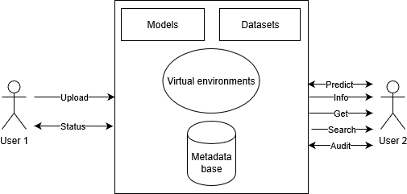

Workflow

## What does **weles** stand for?

Weles is the slavic god of wealth and the shepherd of the souls. For us, **weles** is the god and the shepherd of the machine learning models. He will take care of every model you will upload.

[figure not shown]

Weles

## Is **weles** for me and do I need it?

Yes, if only you:

- train machine learning models and want to share them
- make a research and want to publish your work
- want to reproduce someone’s else results
- want to analyse metadata of the machine learning models
- make a metamodel
- test someone’s models on different datasets
- want to find the model that satisfies your needs
- try to reproduce someone’s else model.

## What can I do in **weles**?

Here are some basic usage examples. **weles** offers much more, however these are the most important.

### Create an account

This is the very beginning of the usage. You need the account for some use cases in the **weles**.

In **R**:

```
users_create()
```

In **Python**

```
users.create()
```

Then you will be asked to type in some credentials.

### Upload

First you need to have a trained machine learning model in **R** or **Python**. **weles** supports $5$ of the most commonly used packages in that matter:

- scikit-learn
- keras
- mlr
- parsnip
- caret

In **R** you just need to type:

```
models_upload(model, 'model_name', 'description of the model', 'target_column', c('just', 'some', 'tags'),
train_data, 'data_name', 'description of the data')

# $id
# '6fda5518-2cbd-47a4-acb6-22fce9fbe35d'
```

In **Python**:

```
models.upload(model, 'model_name', 'description of the model', 'target_column', ['just', 'some', 'tags'],
train_data, 'data_name', 'description of the data', 'python_requirements_file')

# {'task_id': '6fda5518-2cbd-47a4-acb6-22fce9fbe35d'}
```

After passing your nick and password your model will be uploaded. The information about the your environment will be automatically gathered. If the virtual environment satisfying your requirements is not already present in the **weles**, it will be created. You however do not need to wait for its creation - you will get immediately response as the *id*. This *id* refers to the process of creating your environment. To check the progress you can type:

In **R**:

```
models_status(id)
```

In **Python**

```
models.status(id)
```

You will see the progress bar of uploading and get as a final result a short raport.

The upload function has a lot of features, among the others passing the dataset as the hash of one already uploaded.

### Predict

If you want to use already uploaded model for a prediction, you do not need to worry about your environment. Everything is calculated on the server.

In **R**:

```
models_predict('model_name', data)
```

In **Python**

```
models.predict('model_name', data)
```

That’s all. After some calculation on the server’s side you will get the result. Once again, the data could be the hash.

### Search

This function allows you to find the model you want. Here are many parameters that can precisely describe the model you need.

You can specify things such:

- language of the model: R, Python
- version of the language: `=3.4.4, >3.5.2, >3.3.3<3.6.0` and so on
- number of rows in training dataset: `>1520, >5000<1000` and so on
- number of columns in the training dataset
- tags
- regex for the name of the model
- number of classes
- missing values
- owner of the model

Here are some examples:

In **R**:

```
models_search(language='r', language_version='>3.3.3;<3.5.4;')
models_search(language='python', row='>1410;', column='=7;', classes='=14;')
```

In **Python**:

```
models.search(language='r', language_version='>3.3.3;<3.5.4;')
models.search(language='python', row='>1410;', column='=7;', classes='=14;')
```

### Info

If you want to get know some details of the model, you have a function info.

In **R**:

```
models_info('model_name')
models_info('model_name')$target
models_info('model_name')$data$dataset_id
models_info('model_name')$columns
models_info('model_name')$audits
```

In **Python**:

```
models.info('model_name')
models_info('model_name')['target']
models_info('model_name')['data$dataset_id']
models_info('model_name')['columns']
models_info('model_name')['audits']
```

As a response you will get either Python dictionary or R named list with all metadata about the model.

### Audit

If you want to test models in the **weles** you can use the audit function.

In **R**:

```
models_audit('model_name', 'mse', data, 'target_name', 'audit_data', 'description of the audit data')

models_info('model_name')$audits
```

In **Python**:

```
models.audit('model_name', 'mse', data, 'target_name', 'audit_data', 'description of the audit data')

models.info('models_name')['audits']
```

Then model in the **weles** will make a prediction (on server’s side) and will be measured (here in the example with *mse*). The result will be saved in the base, you can access it via the info function.

## Summary

As you can see the interface in **Python** and **R** is nearly identical. User do not have to worry about the language of the model, its version or the packages. They can easily access that information, though.

Here were presented just some basic usage examples and the idea behind them. More can be find in the documentation of the package.

## In the future

Project can be further developed to make a platform for a full virtualization of the models. Where no longer models are trained and used on local computers, but all live in their own virtual environments on a server and all possible operations are made online. Then differences between languages, packages and technologies would only be the matter of the personal taste, because of their common interface.